# 1.Simulazioni

NikolayNikolaev

2023-10-23

# 1. The simulations

## 1.1. Introduction:

Simulations are used for the purpose of imitating – simulating, precisely – operations in the most varied application contexts. A general definition, which common to various contexts is the following:

**Definition 1.1.** The term simulation refers to the fact that a real problem occurs reproduced in an artificially constructed context and therefore perfectly – or to a large extent – controllable.

This is a particular type of experimentation and in fact, an example of simulation are laboratory experiments. These can be seen as reduced-scale reproductions of a real problem which, in this way, is rendered perfectly controllable by the experimenter.

The model is an abstraction, theoretical or real, which summarizes everything that is known about the system, reproducing its essential structural components, properties and relationships between them components.

Symbolic models are logical-formal translations of the system according to a mathematical scheme abstract - for example a system of equations that define an economic model.

Statistical science uses models as a theoretical simplification of reality, in general based on hypotheses and assumptions regarding the functioning of the system itself. If the system is stochastic, the model is consequently a stochastic (symbolic) model which can be thought of as a set of functions, more or less complex, of random variables.

The functioning of a system is studied, through simulation, by simulating realizations from a certain model with the aim of understanding, predicting and controlling the reactions of the real system modeled to artificially determined variations.

The functioning of a system is studied, through simulation, by simulating realizations from a certain model with the aim of understanding, predicting and controlling the reactions of the real system modeled to artificially determined variations.

Artificially producing data from observations – hereinafter referred to as pseudo-data – represents a valid practice for formulating and testing hypotheses on the functioning of the system real. In such contexts, therefore, simulating the system means sampling data from the model. In this context, probabilistic theories and statistics play an instrumental role for other details please refer to (Mecatti et al., 2008).

The traditional scope of simulations has recently expanded, and still does expanding, thanks also to the increase in the computing power of computers. Within political economic complex econometric models are hypothesized and pseudo-realizations are generated from this; in the corporate economic field, for example, the effects of a campaign are simulated investments on the sales of a large company in relation to a specific model. The simulations they are often required to validate a new model and are reported in many scientific articles.

The development of simulations in statistics, as well as in other fields, is strictly linked to technological and IT advancement. The first stochastic simulations conducted at computer date back to around 1944. However, examples of simulations are encountered on various occasions even in less recent history. Among these we can remember the procedure known as Buffon needle dating back to the second half of the 18th century by G.L. Lecrerc Comte de Buffon (1707-1788). The original experiment, which had as its objective the decimal approximation of the irrational number $\pi$, did not, of course, use a calculator but a needle thrown at a large number of times on a plane with a Cartesian reference. Later, in 1899, Lord Rayleigh proposed the use of a particular stochastic process, known as random walk (which will be covered in the Bayesian inference course) to provide an approximate solution to a parabolic differential equation.

In 1931 Kolmogorov, to whom we owe the modern axiomatic approach to the calculus of probability, he demonstrated the connections between the process called Markov chains, another type of stochastic process (which will be treated during the Bayesian inference course) and particular differential equations using a stochastic simulation. In 1908 Student, pseudonym of W.S. Gosset, employed stochastic simulation, or artificially sampling experiments conducted, to develop his famous distribution called Student’s T. And there are many more the examples that can be cited as precursors of modern stochastic simulations al computer.

Statistical simulations are essentially stochastic simulations in which models they are random variables or stochastic processes with a given probability law. The foundations for building a stochastic simulation are therefore represented by the ability to produce artificially – it is said to generate by computer – determinations from certain random variables.

The generation of determinations from random variables to the computer uses so-called pseudo-random numbers.

## 1.2. Pseudo-random numbers:

The stochastic simulation involves the execution of the following steps: 1. the generation of random numbers; 2. the generation of determinations of particular random variables with a pre-assigned law of chance; 3. the use of the values generated for the solution of statistical problems through simulations stochastic.

Over the years, with the development of information technologies, the methods of generation of random numbers. In stochastic simulations, large sets of are used random numbers. We then speak of a series of random numbers whose (modern) definition is reported right away.

Definition 1.2. A random number series is a set of real numbers between 0 and 1 that represent a Bernoulli sample of determinations from a Uniform random variable (continued) on the interval (0,1).

For this reason we speak more precisely of uniform random numbers. Modern generators random numbers are based on algebraic-recursive devices implemented on the computer, i.e series of numbers are produced using an algorithm. Thus, if on the one hand the advantage of overcoming the main drawbacks of mechanical and physical/natural generators is obtained, on the other introduces the obvious disadvantage due to the loss of randomness in the generation process and, consequently, in the numbers generated.

In fact, the numbers produced on the computer by algebraic-recursive generators are the result of a ordered and finite series of logical-mathematical operations – precisely the algorithm1 – in which nothing is random and everything is deterministic. Furthermore, the recursion of the generator, which uses a number generated previously to produce the next number, contrasts with the request for independence between the numbers of the series, inducing an evident correlation.

Faced with a series of numbers generated by a computer-implemented algorithm, the question which makes no sense to ask is “is this sequence random?”, since the answer is certainly no, but “this sequence will behave as if it were random once applied to the problem of interest?”. For this reason, we speak more precisely of pseudo-random numbers. In a pseudo-random series, the numbers have the appearance of randomness, that is, they appear independent and equiprobable or appear as determinations of the random variable Uniform on the interval (0.1).

In other words, to pursue the advantages offered by computer generation already mentioned, we give up the randomness of the series to settle for pseudo-randomness.

** The word “algorithm” has its roots in the Latinization of the name of Persian mathematician Muhammad ibn Musa al-Khwarizmi

In summary, the properties of a good algebraic-recursive generator are the following: 1. produces series of numbers that appear uniformly distributed on the interval (0,1) and which do not show correlation or other type of dependency structure; 2. it is fast enough for simulation purposes and has sustainable memory needs; 3. guarantees the reproducibility of any series produced: this allows, for example, the validation of the simulation results and comparisons of the same simulation conducted on different models/systems, keeping variations under control.

The goodness of the generator affects the simulation results, determining their quality and reliability validity. There is a vast literature in this field that involves various disciplines and skills: abstract algebra, number theory, computer science, hardware engineering and statistics.

The goodness of the generator affects the simulation results, determining their quality and reliability validity. There is a vast literature in this field that involves various disciplines and skills: abstract algebra, number theory, computer science, hardware engineering and statistics.

In particular, a moment of verification of the pseudo-randomness of the series is necessary used, or the goodness of the generator used. These tests are called Random Tests. Going into detail about algebraic-recursive generators goes beyond that of the aims of this course. Therefore, in the following we introduce the main one in a simple way linear generator to identify its salient characteristics.

## 1.2.1 Congruential methods

The methods currently used, which best respond to the properties required of a good algebraic-recursive generator, are known as linear congruential methods because they are based on a linear congruential relation due to the modulus operation of an integer m:

Definition 1.3. Module division

The number *x* modul $m \in N$ is

$$x mod m = x -
[\frac{x}{m}]m$$

where $[x]$ indicates the integer part of x (i.e. the large integer less than or equal to x)

Example:

Let them be x = 1, 2, . . . e m = 4. The calculation of division in modulus x mod m by successive numbers is the following:

$$1 mod 4= 1- [\frac{1}{4}]4= 1- 0.4 =
1$$
$$2 mod 4= 1- [\frac{2}{4}]4=
2- 0.4 = 2$$
$$3 mod 4= 1-
[\frac{3}{4}]4= 3- 0.4 = 3$$
$$4 mod
4= 1- [\frac{4}{4}]4= 4- 0.4 = 0$$
$$5 mod 4= 1- [\frac{5}{4}]4= 5- 0.4 = 1$$
$$6 mod 4= 1- [\frac{6}{4}]4= 6- 0.4 =
2$$
$$7 mod 4= 1- [\frac{7}{4}]4=
7- 0.4 = 3$$
$$8 mod 4= 1-
[\frac{8}{4}]4= 8- 0.4 = 0$$
$$.......................................$$

As can be seen from the inspiring example, the result consists only of integers: the integers 0,1,…., m-1.

Modern algebraic-recursive generators employing linear congruent methods are based therefore on the idea that the rest of the division - the module precisely - is sufficient irregular to simulate randomness.

## Mixed congruential method:

It is the most general of the linear congruential methods, introduced by Lehmer in 1951.

If $x_i$ is the i-th number generated, then the next $(i+1)$-th is given by the following (linear congruential) reaction.

$x_{i+1}= (a.x_i + c)$ mod $m$

where a, c, m are non-negative integers called multiplier, increment and modulus respectively.

The initial value $x_0$ is called the seed of the generator and represents the device of reproducibility of the generated series. In fact, since the series of numbers is produced deterministically, the same value $x_0$ always produces the same series.

Generally, and with the aim of producing different series, the seed x0 is assigned based to the last value of the last generated series or based on the clock (the internal clock) of the machine on which the generator is implemented. Since xi is the result of a module operation and takes the values 0, 1, 2…m−1, then a pseudo-random number according to the modern definition indicated with $u_i$ is obtained as a ratio: $u_i= x_i/m$

Example: 1.2

With choices $a=c=x_0=3$ e $m=5$, from equation (1.1.) the following series is produced:

$$x_0=3$$
$$x_1= (3x3+3)mod5= 12-[12/5]=2$$
$$x_2= (3x2+3)mod5= 9-[9/5]=4$$
$$x_1= (3x4+3)mod5= 15-[15/5]=0$$
$$x_1= (3x0+3)mod5= 3-[3/5]=3$$

Having obtained the starting value, it is evident that $x_i=x_{i-4}$ per $i=5,6...$

Again for the fact that $0=< x_i < m$, and immediately identify a further drawback of the Recursive algebraic generators based on linear congruential methods, i.e. their periodicity. In fact, the generated values that are different from each other are at most m and, after a certain number of iterations, the numbers will begin to repeat themselves, that is, to present a systematic nature, consequently losing the requirement of apparent randomness.

The periodicity, uniformity and density in (0,1) of the generated values depend on the generator parameters: the seed, the multiplier, the increment and the modulus; therefore they can be controlled by appropriate choices of these constants.

It is required that the generator has a sufficiently long period and that the generated values are sufficiently dense in (0,1) for uniformity.

Marsaglia (1968) verified that with the following equation

$$x_{j+1}= 65539(x_j)mod2^31$$

numbers are generated which for each linear sequence have a non-random trend. There is one vast technical literature on this subject, so today we have theorems that indicate the choices most appropriate to pursue the objectives listed above. Some indications are the following: - $m$ is a rather large prime number - $c$ is a prime integer relative to $m$ (e and m have no common divisors except 1) - a is of the form $2^r +1 $ with >=2;

The IBM 360/370 machines, which were used in the 1980s, were equipped with a generator with parameters: $a=2^16+3,c =0, m=2^{31}-1$ which, today, is known to be rather poor under the profile of pseudo-randomness, periodicity and uniformity. For other proposals see also https://en.wikipedia.org/wiki/Wichmann%E2%80%93Hill.

Currently, the choices: $m=2^{35}, a=2^7+1, c=1$ are considered acceptable and exist many types of tests to evaluate the randomness of the generated series, see for example above Wikipedia randomness tests http: //en.wikipedia.org/wiki/randomness_test.

The multiplicative congruential method derives from the mixed method by setting the increment c equal to zero hence the name: $x_{i+1} a.x_i$ mod $m$

Similar to the mixed method, a uniform random number is obtained from the ratio: $u_i=x_i/m$

Example: 1.3.

Posing $a=x_0=7,m=11$ equation (1.2) generates the following series:

$$x_0=7$$
$$x_1=7x7 mod 11= 49-[49/11]11=5$$
$$x_2=5x7 mod 11= 35-[35/11]11=2$$
$$x_3=2x7 mod 11= 14-[14/11]11=3$$
and so on…

## 1.2.2 Continuous Uniform Random Variable:

A continuous random variable with the following density function is called rectangular:

$$\begin{equation}
x+y =
\begin{cases}
\frac{1}{b-a} & a =< x =< b \\
0 & \mbox{otherwise}
\end{cases}
\end{equation}$$

con $-\infty < a< b< \infty$

It is a symmetric function with center at $x=(a+b)/2$ which is the central point of the interval closed [a, b]. The density function is zero for values outside the interval. The moments that define the expected value and the variance are the following

$$E[X]= \frac{a+b}{2}$$

$$Var[X]= \frac{(b-a)^2}{12}$$

$$E[Y]= r$$
$$Var[Y]= 2r$$

1.3. Randomness test:

1.3 Randomness test Any iterative generator implemented on the computer produces completely deterministic and serially dependent series of numbers. It is necessary to verify the pseudo-randomness of the series generated that is: - the series has the appearance of a random (uniform) series; - the numbers in the series behave as stochastically independent. When this is achieved, the series produced by the computer can be used as a series of random numbers being similar to a set of determinations independent of a variable random Uniform at (0,1).

1.3.1. Empirical tests:

Empirical tests are used to evaluate the pseudo-randomness of a series of numbers produced on the computer by an iterative generator. For example, if you use a random number generator to simulate the distribution of an estimator that is known to be unbiased, the simulation results must be compatible with this notion; in other words the simulated distribution must have an average sufficiently close to the expected value of the parameter being estimated.

A second method, simple and natural, classifiable as an empirical test, is the graphical evaluation of the apparent equiprobability and independence of the generated numbers. For a series of n numbers, that is can be realized with respect to the Cartesian plane in the following way.

- The numbers are represented, in the order in which they were produced, as points on the Cartesian plane. If the points appear well spread out in the rectangle (0,n)×(0,1) this is an indication of (apparent) equiprobability; they must present themselves without clusters or particular tendencies when present (apparent) independence.
- Similarly, the representation with the scatter diagram in the rectangle can be used (or portion of plane) (1, n − 1) × (2, n). In practice, the current value is considered compared to the previous value of the series. In this way any serial correlations can be visualized.
- If n is large, a histogram of the frequency density distribution of i is constructed points in a set of arbitrary subintervals of the interval (0,1). The distribution represented must appear sufficiently uniform or must have a sufficient shape similar to the rectangle (0.1)×(0.1).

1.3.2. Statistical tests: The most suitable way for us to evaluate the quality of a generator, i.e. pseudo-randomness of a computer-generated series, is the execution of statistical tests. These tests follow the logic according to which a computer-generated series of n numbers is seen as a Bernoulli sample of size n from the random variable Y with distribution function (f.r.) F (y). The hypothesis is formulated that Y is a Uniform random variable in (0,1); formally:

$$H_0: F(y)= F_0(y)=y$$
- $0=< y=<1$

The problem is therefore formulated as the verification of hypotheses on the functional form of the f.r. F (y) and the statistical tests based on this logic are called Goodness of fit tests. Note that the null hypothesis H0 is simple since F0 (y) does not depend on unknown parameters or is completely specified.

In the following we consider the Kolmogorov-Smirnov tests and the Chi Square test which are two tests statistics adapted as random tests for the context under consideration. The first test is based on notion of Empirical Distribution Function.

#### Empirical distribution function:

Definition 1.4. Given a Bernoulli sample of size n from the random variable and considering the n sample values $x_i =< x_{i+1}, i=1///n-1$, the empirical distribution function $Fde$ is called the empirical distribution function $\hat{F_n}$ with values in ’interval [0,1] which assigns to each x its sampling weight 1/n
$$\hat{F_n}: R-> (0,1)$$

such that:

In a situation of total absence of information about the probability law F of the variable random from which the sample is drawn, the Fde can be assumed as an estimate of F.

Some theoretical reasons that justify the use of empirical distribution functions are the following. Observe that, for a fixed $x\in R$, as the sample in X varies the Fde describes a random variable interpreting the (relative) frequency of the event ($X_i =< x$) which, a priori, has probability F(x) of occurring, constant at each extraction. Therefore, due to the independence of the n extractions, this random variable takes on the values $i/n, i=1...n$ and has a Binomial distribution of parameters n and F(x) and therefore has a mean F(x) and variance $ F(x)[1-F(x)]/n$ It follows that for, every $x\in R$ the Fde is undistorted and consistent for the unknown F. - $E[\hat{F_n}]= F(x)$- correctness - $MSE- \frac{F_n(x)(1-F_n(x))}{n}-> 0$ = consistency - la variabile casuale descrittiva da $\hat{F_n}$ converges uniformly to the true Faith by the Glivenko-Cantelli theorem -1933 $\\hat{F_n(x)}-> F(x)$

The test is carried out empirically by comparing the adherence of the function on a graphic level of empirical distribution of the values generated with the theoretical one specified by the null hypothesis. Please refer to the application fees for further details.

### Kolmogorov-Smirnov test

The Kolmogorov-Smirnov (K-S) test exploits the properties of the f.d.r. and can be used to test for pseudo-randomness. Let the vector $y_1...y_n$ be the series of numbers whose pseudo-randomness you want to verify, seen as a Bernoulli sample from the random variable Y with f.r. F(y).

The following hypothesis is considered
$$H_0: \hat{F_n}(y)= F_0(y)=y$$
- $0=< y=< 1$

If $H_0$ is true, as n increases, the Fde will be increasingly closer to $F_0(y)$

A method to establish the goodness of fit of $F_0(y)$ to the data - that is to the series of numbers subjected to verification - is then to establish some measure of distance between the two functions $\hat{F_n}(y)$ and $F_0(y)$ and reject $H_0$ if this distance is too high. The distance used by the K-S test is simply the vertical distance between the values assumed by $\hat{F_n}(y)$ and from $F_0(y) corresponding to each of the n numbers $y_i$ available, the experimental value of the test is then the largest between these distances:

$$d_n= sup_{y\in\{
y_1...u_n\}}|\hat{F_n}(y)- F_0(y)|= sup_{y\in\{
y_1...u_n\}}|\hat{F_n}(y)- y|$$

The K-S test allows you to verify the adaptation to the hypothesized distribution of each of the n series numbers. Equation (1.3) will tend to provide values close to zero if H0 is true e positive values far from zero if $H_0$ for high values of $d_n$ or to concentrate the critical region of the test on the right tail.

As the sample varies, $d_n$ describes the random variable $D_n$ (test statistic) whose exact distribution, under $H_0$, is tabulated for small values of n. . In particular, once the significance level $(1-\alpha)$ is fixed, the tables provide the order quantile $(1-\alpha)$ of the random variable $D_n$, i.e. the value $d_{} $ solution of the equation $\alpha= P(rif.H_0|H_o)= P(D_n > d_{\alpha})$ , which represents the critical value of the test. The statistical test is if $H_0$ is rejected, a level $(1-\alpha)*100$% , if $d_n >= d_{\alpha}$. Rejecting $H_0$ we conclude that the series of numbers generated by the computer is not pseudo-random and, if this conclusion is reached, yes arrives for a high percentage of different series of numbers produced by the same iterative generator, one is led to doubt the quality of the latter.

For large values of n Kolmogorov proved the following asymptotic result:

$$lim_{n->\infty} P(\sqrt{x}D_n =< x
)= 1- 2\sum_{j=1}^{\infty}(-1)^{j-1} exp(-2j^2x^2)=$$

$$\frac{\sqrt{2\pi}}{n}
\sum_{j=1}^{\infty} exp(-(2j-1)^2 \frac{\pi^2}{8x^2})= H(x)$$
- $x>0$

#### Chi-Square Test:

The test is based on the connection index $\chi^2$ 2 which compares the observed frequencies and the expected or theoretical frequencies. The same Pearson, and later Cram´er (1946), Fisher and others, have shown that statistics, based on the comparison between observed frequencies and expected frequencies, they have asymptotic distribution Chi Square with a certain number of degrees of freedom (dof) when the null hypothesis H0 is assumed true.

In particular, in the case of the context under examination, these are frequencies expected under the hypothesis according to which the n sample values – i.e. the series generated and subjected to verification of pseudo-randomness – come from a Uniform random variable in (0,1).

Let (y_1…y_i…y_n) be the series of n numbers produced by the computer and:
$$H_0: F(y)= y$$
$0=< y=< 1$ the null hypothesis.

The interval [0, 1] is divided into k disjoint subintervals $I_j, j=1...k$ with k integer predetermined. . Since the Uniform random variable has a constant and even density function (f.d.). at 1 on this interval, the expected frequencies based on H0 are defined as follows:

$$np_j^0= n.(ampiezza del sottointervallo
I_j)$$

The observed frequencies are given by

$$n_j = \# (y_i \in I_j;
i=1...n)$$

Where the symbol # is “the number of”, that is, the absolute frequency of the numbers in the series that fall within the j-th subinterval.

The experimental value of the test is
$$x^2 = \sum_{j=1}^k \frac{(n_j -
np_j^0)^2}{np_j^0}$$

Operationally, the interval [0, 1] is divided into equal subintervals amplitude 1/k. In this way the expected frequencies are constant and equal to $n.p_j^0=n/k, j-1...k$ and the experimental value of the test takes on the following formulation:

$$x^2 = \frac{k}{n} \sum_{j=1}^k (n_j -
\frac{n}{k})^2$$

which will tend to provide values close to zero if H0 is true and positive values far from zero if H0 is false. Consequently, we are led to reject H0 for large values of $x^2$ or to concentrate the critical region of the test on the right tail. As the sample varies, $X^2$ describes the random variable $X^2$ (test statistic) with asymptotic distribution, under $H_0$, Chi-Square with (k-1) dof. Set the significance level $(1-\alpha)$ for n sufficiently large, the critical value of the test is the order quantile ($1-\alpha$) of the random variable Chi- Square conk-1 dof. i.e. the value $\chi_{k-1; 1-\alpha}^2$ solution of the equation

$$\alpha = P(rifiutare H_0|H_0) \sim P(X^2
>= \chi_{k-1;1-\alpha})$$

H0 is rejected, at level $(1-\alpha)*199$ if $x^2 >= \chi_{k-1'1-\alpha}^2$. If you refuse $H_0$, we conclude that the series of numbers generated by the computer is not pseudo-random. If at one this conclusion is reached for a high percentage of different series of numbers produced by the same algebraic-recursive (or, even, iterative) generator, one is led to doubt the quality of the latter.

We observe that: - the approximation of $X^2$ to $\chi_{k-1}^2$ is asontptic, i.e. it improves as n increases.

- An empirical rule recommends that $n_j >= 5, j=1...k$. It is therefore convenient to choose k in such a way that this condition is respected: the smaller k is, the easier it is for this condition is satisfied. However, it should be kept in mind that the choice of k affects the degrees of freedom and therefore on the critical value of the test.
- If the Chi-Square approximation is not good because n is not high enough or if not all the observed frequencies are at least equal to 5, the risk we run is that the level actual significance level of the test is far from the pre-established nominal level ($1-\alpha$). This is a typical situation that can be investigated through simulations.

#### Absence of autocorrelation test:

$$\gamma(t, t+k) = E[(X_t - \mu_t)(X_{t+k}
- \mu_{t+k})]$$
- where $\mu_t$ is the average value calculated with respect to t and $\mu_{t+k}$ is the one calculated for the series at lag k.

If the process generating the data is stationary, that is, if each h-tuple $(X_{t1}... {t_h +k})$, then means, variances and autocovariances of $X_y$ are independent of k and the autocovariance function depends only on k and not on t si denote by $\gamma(k)$

The autocorrelation function at lag k is given by

$$\rho(k) = Corr(X_t, X_{t+k})=
\frac{\gamma(k)}{\gamma(0)}$$

and for the Cauchy-Schwarz2 inequality it is between -1 and 1 and depends by the delay length k but is constant over time.

Note that under the assumption that the pseudo-random number generator produces observations similar to independent realizations from identically distributed variables, the data generating process is stationary. One way to verify the absence of serial correlation of a sequence of observations is to test the hypothesis of absence of autocorrelation such that:

$$H_0: \rho(k) = 0$$

The autocovariance is estimated with the following plug-in estimator

$$\hat{\gamma(k)} = \frac{1}{n}
\sum_{t=1}^{n-k}[(X_t - \bar{X})(X_{t+k} - \bar{X})]$$

Under the hypothesis $H_0$ the asymptotic result holds:

$\sqrt{n}\hat{\rho_n}(k) \sim N(0,1)$

so, for large n, approximately, $\rho_n}(k) \sim N(0,1)$

The graphical analysis of the sample autocorrelation function allows you to

```
$Cov(X,Y) =< \sqrt{Var(X)Var(Y)}$
```

check whether approximately $(1-\alpha)*100$% of the autocorrelations are, in absolute value, less than $z_{1-\alpha/2} / \sqrt{n}$ (with $z_{1-} $percentile of standard normal)

# Demonstration:

Below we show an example that implements a mixed congruential linear algorithm for the generation of pseudo-random numbers. The function of R called below is also reported runif.

## Linear congruential method:

The mixed congruential generation method is used in which the following quantities are present. A succession of values is generated in a deterministic way that appears causal. The generator has the following structure:

$x_{i+1} = (a.x_i + c)$ mod $m$

We apply it by specifying the following values:

$x_{i+1} = [(2^16)+1]*47838 + 5$ mod $34359738368$

That is to say: - the multiplier is $a=2^16 + 1 = 65537$ - the initial value or seed: $x_0 = 47838$ - the increase: $c=5% - the model: $m = 34359738368$ e $2^{\beta}= 2^{35}$

Result: 1. First number generated:

```r
a    <- 65537
m    <-34359738368
xini <- 47838
c    <- 5
(a*xini + c)%%m
```

```
## [1] 3135159011
```

From which the first pseudo-random number is obtained by dividing by the modulus

```r
x1 <- (a*xini+c)%%m
x1/m
```

```
## [1] 0.09124514
```

Second number: the next value is obtained from the one obtained previously:

```r
(a*x1 + c)%%m
```

```
## [1] 32040401640
```

```r
x2 <- (a*x1+ c)%%m
x2/m
```

```
## [1] 0.9324984
```

The following iterative construct allows you to generate a sequence of 1857 pseudo-random numbers le whose determinations are saved in the random.n vector

```r
n <- 1857
random.n <- numeric(n)
for(j in 1:n){
x1 <- (a*x1+c)%%m
random.n[j] <- x1/m
}
head(random.n)
```

```
## [1] 0.9324984 0.1487612 0.3650336 0.2063155 0.2976069 0.2639079
```

```r
tail(random.n)
```

```
## [1] 0.6885469 0.2974622 0.7813871 0.7653215 0.8742654 0.7332189
```

Please refer to the Random help for information on the R generator. The default method is “Mersenne-Twister”.

The set.seed function requires an integer to specify the seed in R.

## 2.Evaluation of the pseudo-randomness of the series

Descriptive statistics:

```r
require(skimr)
```

```r
skim_without_charts(random.n)
```

Data summary

| Name | random.n |
| --- | --- |
| Number of rows | 1857 |
| Number of columns | 1 |
| _______________________ |  |
| Column type frequency: |  |
| numeric | 1 |
| ________________________ |  |
| Group variables | None |

**Variable type: numeric**

| skim_variable | n_missing | complete_rate | mean | sd | p0 | p25 | p50 | p75 | p100 |
| --- | --- | --- | --- | --- | --- | --- | --- | --- | --- |
| data | 0 | 1 | 0.5 | 0.29 | 0 | 0.25 | 0.5 | 0.75 | 1 |

```r
var(random.n)
```

```
## [1] 0.08328912
```

The position indices are in line with those expected with respect to the uniform distribution la whose random variable has an expected value of 1/2. The variance conforms to the theoretical one 1/12 = 0.08333.

Graphic tests

1. Scatter diagram

The first graphical test is the scatterplot on the plane (1, 𝑛 − 1) ⋅ (2 ∶ 𝑛)

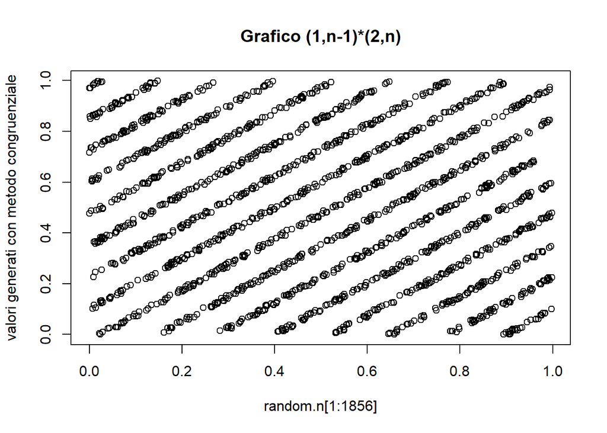

```r
plot(random.n[1:1856],
random.n[2:1857],
main="Grafico (1,n-1)*(2,n)",
ylab = "valori generati con metodo congruenziale")
```

You notice that the points are in sequence and are not scattered across the plane randomly like they should be if they were independent observations. If there was independence every couple of points $(𝑢_, _{𝑖−1})$ should be placed with equal probability on the plane. The graph highlights that the generator is not adequate.

Verify that it is sufficient to simply increase the value assigned to the term 𝑐 (increment), for example by setting 𝑐=235 so that the series no longer presents this trend in graph a dependency.

3. Histogram

The histogram allows you to evaluate the frequency density for each class of values. Below, the histogram is drawn by fixing 20 classes and the average observed value is added in addition to the text in the graph.

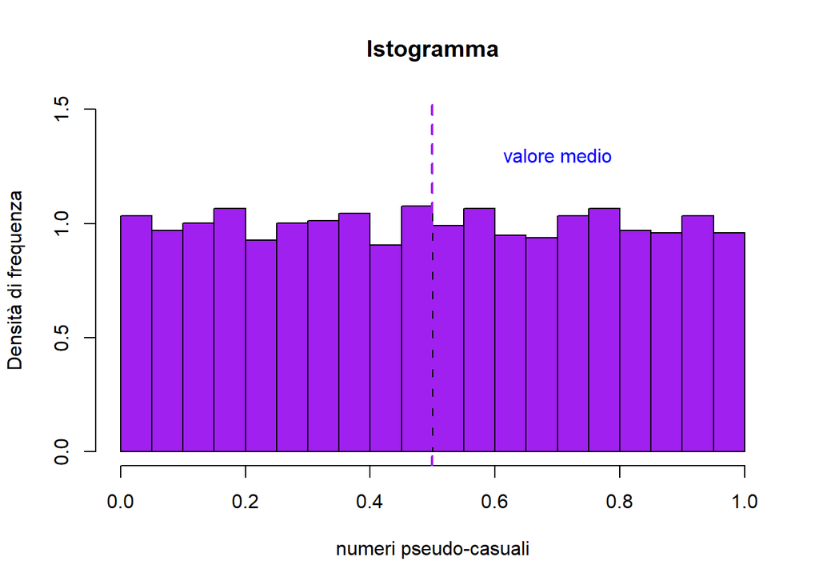

```r
hist(random.n, col = 'purple',
  breaks = 20,
  freq=FALSE,
  ylim =c(0,1.5),
  main='Istogramma',
  xlab='numeri pseudo-casuali',
  ylab='Densità di frequenza')
  abline(v=mean(random.n),
  col='purple',
  lwd=2,lty=2)
  text(0.7,1.3,
  c("valore medio"),
  col="blue")
```

It is noted that the frequency densities are approximately similar and around the value 1. The graph is similar to that expected under the hypothesis of uniform distribution [0, 1].

3. Empirical distribution function

The following graphical test allows you to compare the empirical distribution function and the theoretical one obtained with the native function of R.

In the following chunk, first the empirical distribution is drawn and then the theoretical one is added and finally the legend is added to the graph.

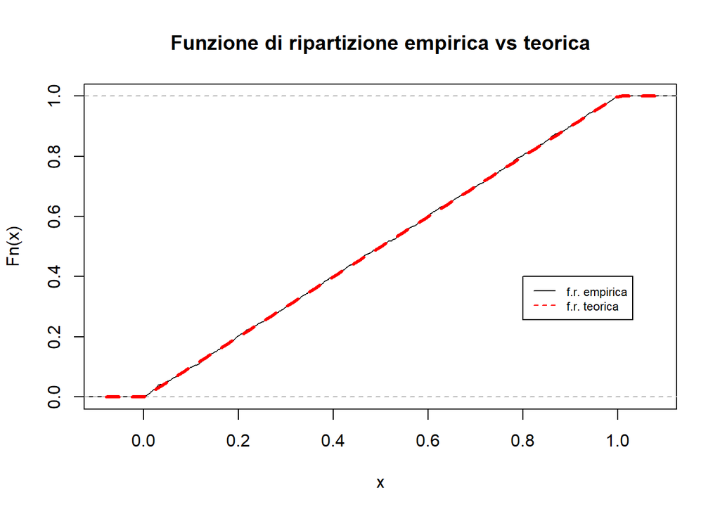

```r
plot(ecdf(random.n),
do.points=FALSE,
main ='Funzione di ripartizione empirica vs teorica')
curve(punif(x,0,1),
lty='dashed',
col='red',
lwd='3',
add=TRUE)
legend(0.8,0.4,
col=c("black","red"),
c("f.r. empirica","f.r. teorica"),
lty=c(1,2),
cex=0.7)
```

There are no particular differences between the two distribution functions compared.

Kolmogorov-Smirnov test

The non-parametric test that allows you to compare the empirical distribution function with the theoretical one of the uniform distribution is carried out with the ks.test function.

From the theory notes we remember that the test statistic is based on the maximum difference in modulus between the two distribution functions.

Under the null hypothesis that the two distribution functions are equal, the distribution is used asymptotic (large n) of the test statistic (Birnbaum & Tingey, 1951).

```r
ks.test(random.n, "punif")
```

```
##
##  Asymptotic one-sample Kolmogorov-Smirnov test
##
## data:  random.n
## D = 0.0095202, p-value = 0.996
## alternative hypothesis: two-sided
```

The observed value of the test statistic is 0.009 and the defined area is close to 1. The level of significance observed p-value is greater than 0.1.,0.05, 0.01 therefore the test leads to accept the null hypothesis that the data are realizations of the uniform random variable in [0, 1].

Chi Square Test

To perform this test, the relative frequency of the values observed for each of the values is calculated subintervals

```r
n <- length(random.n)
int<-seq(0,1,by=0.1); int
```

```
##  [1] 0.0 0.1 0.2 0.3 0.4 0.5 0.6 0.7 0.8 0.9 1.0
```

```r
foss<-table(cut(random.n, int))/n; foss
```

```
##
##    (0,0.1]  (0.1,0.2]  (0.2,0.3]  (0.3,0.4]  (0.4,0.5]  (0.5,0.6]  (0.6,0.7]
## 0.10016155 0.10339257 0.09639203 0.10285407 0.09908454 0.10285407 0.09423802
##  (0.7,0.8]  (0.8,0.9]    (0.9,1]
## 0.10500808 0.09639203 0.09962305
```

The observed frequencies are compared with those expected based on the hypothesis that the determinations are generated by the uniform distribution

```r
p1 <- rep(0.1, 10); p1
```

```
##  [1] 0.1 0.1 0.1 0.1 0.1 0.1 0.1 0.1 0.1 0.1
```

The chisq.test function allows you to perform the test in the following way

```r
chisq.test(foss,p=p1)
```

```
##
##  Chi-squared test for given probabilities
##
## data:  foss
## X-squared = 0.0011312, df = 9, p-value = 1
```

The 𝑝 − 𝑣𝑎𝑙𝑢𝑒 is close to 1.

The critical value of the test statistic if the null hypothesis is true is determined by setting a value for the first type error for example 𝛼 = 0.05 as follows

```r
qchisq(0.95,df=9)
```

```
## [1] 16.91898
```

Since the critical value of the test is equal to 17, this is much greater than the observed value (0.0011) and the test does not allow rejecting the null hypothesis for every level of significance.

Therefore, also on the basis of this test, the determinations are similar to those of one uniform distribution in [0, 1].

The test must be performed for other (many) series of numbers generated with the congruent generator previous (changing the seed) to accurately evaluate the quality of the generator.

Note that in real situations where sample data are considered the test must be carried out using absolute frequencies and not relative frequencies because otherwise the conclusions may be erroneous depending on the sample size.

In the present context it is necessary to simulate a large series of pseudo-random numbers for which it is still possible to use relative frequencies. With absolute frequencies the test is as follows

```r
n <- length(random.n)
int<-seq(0,1,by=0.1); int
```

```
##  [1] 0.0 0.1 0.2 0.3 0.4 0.5 0.6 0.7 0.8 0.9 1.0
```

```r
fossN<-table(cut(random.n, int)); fossN
```

```
##
##   (0,0.1] (0.1,0.2] (0.2,0.3] (0.3,0.4] (0.4,0.5] (0.5,0.6] (0.6,0.7] (0.7,0.8]
##       186       192       179       191       184       191       175       195
## (0.8,0.9]   (0.9,1]
##       179       185
```

```r
chisq.test(fossN)
```

```
##
##  Chi-squared test for given probabilities
##
## data:  fossN
## X-squared = 2.1007, df = 9, p-value = 0.9898
```

Empirical autocorrelation function

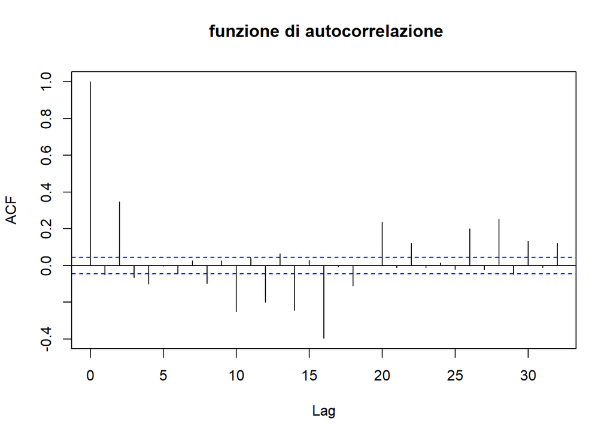

```r
acf(random.n,
main = " funzione di autocorrelazione")
```

The graph is used for time series as the data is generated at successive moments. The graph shows the correlation value determined between two values of the series with $𝑘 = 𝑙𝑎𝑔$: values are correlated: serial dependence. As the length of the interval increases, the correlation between 𝑋𝑡 and 𝑋𝑡+ℎ is expected to decrease. The way in which the autocorrelation function tends to zero is considered as a measure of memory process

In the first graph you can see some values that deviate from the expected ones.

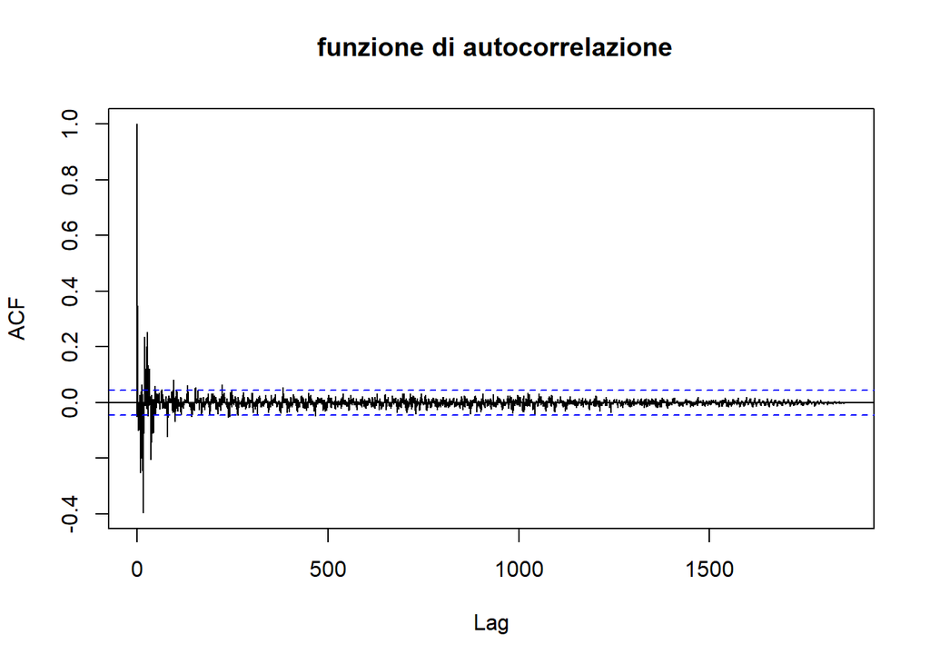

```r
n<-length(random.n)
acf(random.n, main = " funzione di autocorrelazione", lag.max =n)
```

Even in the graph with lag equal to 1 the observations are dependent. Indeed at the level antitotic the following distribution holds

$$\hat{p} \sim N(0,1/n)$$

We note some values higher than the threshold values (dashed lines) based on the hypothesis of underlying stationary process. This graph suggests that the determinations are not independent as already noted in graph of the points placed on the Cartesian plane.

Runif function

In the following, we use the R generator which is called with the runif function and repeats i previously performed tests on this new set of pseudo-random number realizations. Note that the set.seed function defines the initial value and allows it to be generated always the same values.

```r
set.seed(3882)
n <- 2000
rand <- runif(n, min=0, max=1)
head(rand)
```

```
## [1] 0.5768151 0.4648768 0.5794360 0.3892577 0.4496224 0.5984687
```

1. scatter diagram

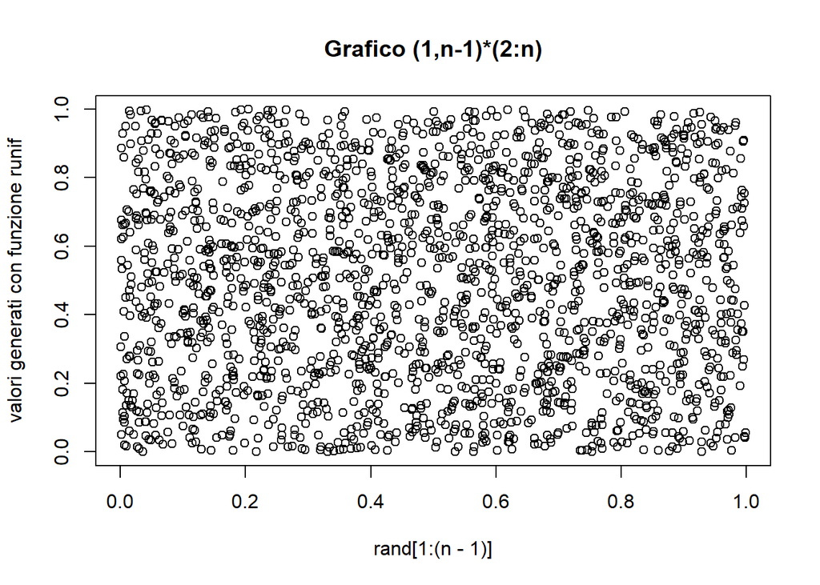

```r
plot(rand[1:(n-1)],
rand[2:n],
main="Grafico (1,n-1)*(2:n)",
ylab = "valori generati con funzione runif")
```

You can see that the points are randomly scattered across the plane.

2. Empirical distribution function

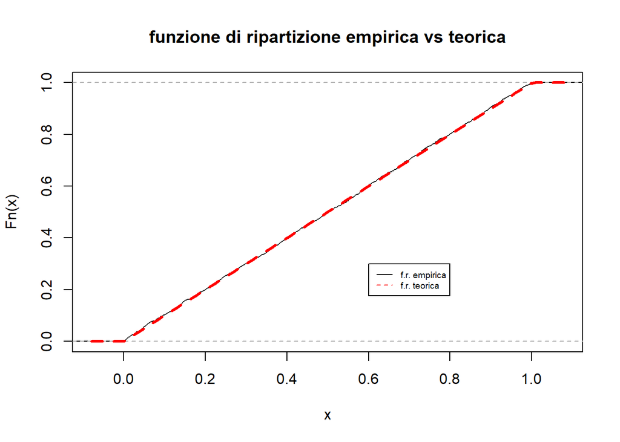

```r
plot(ecdf(rand),
do.points=FALSE,
main ='funzione di ripartizione empirica vs teorica')
curve(punif(x,0,1),
lty='dashed',
col='red',
lwd='3',
add=TRUE)
legend(0.6,0.3,
       col=c("black","red"),
c("f.r. empirica","f.r. teorica"),
lty=c(1,2),
cex=0.6)
```

There are no particular differences between the two distribution functions.

3. Histogram

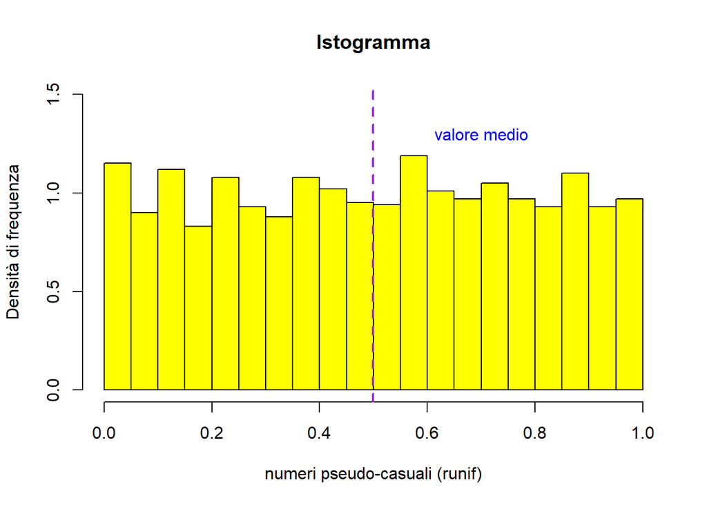

```r
hist(rand, col = 'yellow',
breaks = 20,
freq=FALSE,
ylim =c(0,1.5),
main='Istogramma',
xlab='numeri pseudo-casuali (runif)',
ylab='Densità di frequenza')
abline(v=mean(random.n),
col='purple',
lwd=2,lty=2)
text(0.7,1.3,
c("valore medio"),
col="blue")
```

The density appears almost uniform.

Compared to the graphs referring to the series of numbers obtained with the congruential method, these the latter lead to accepting the hypothesis that the determinations come from a distribution uniform.

Statistical tests also confirm this statement.

Statistical tests

Kolmogorov-Smirnov

```r
ks.test(rand, "punif")
```

```
##
##  Asymptotic one-sample Kolmogorov-Smirnov test
##
## data:  rand
## D = 0.011039, p-value = 0.9678
## alternative hypothesis: two-sided
```

Chi Square

```r
foss<-table(cut(rand, int))/n; foss
```

```
##
##   (0,0.1] (0.1,0.2] (0.2,0.3] (0.3,0.4] (0.4,0.5] (0.5,0.6] (0.6,0.7] (0.7,0.8]
##    0.1025    0.0975    0.1005    0.0980    0.0985    0.1065    0.0990    0.1010
## (0.8,0.9]   (0.9,1]
##    0.1015    0.0950
```

Autocorrelation

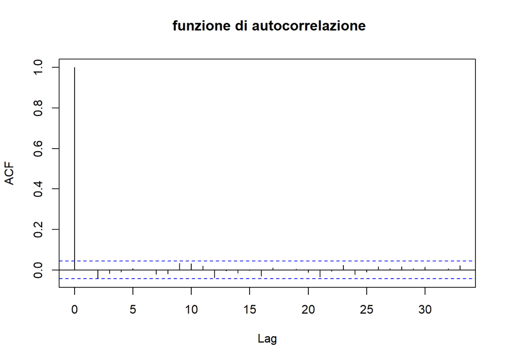

```r
acf(rand,
main = " funzione di autocorrelazione")
```

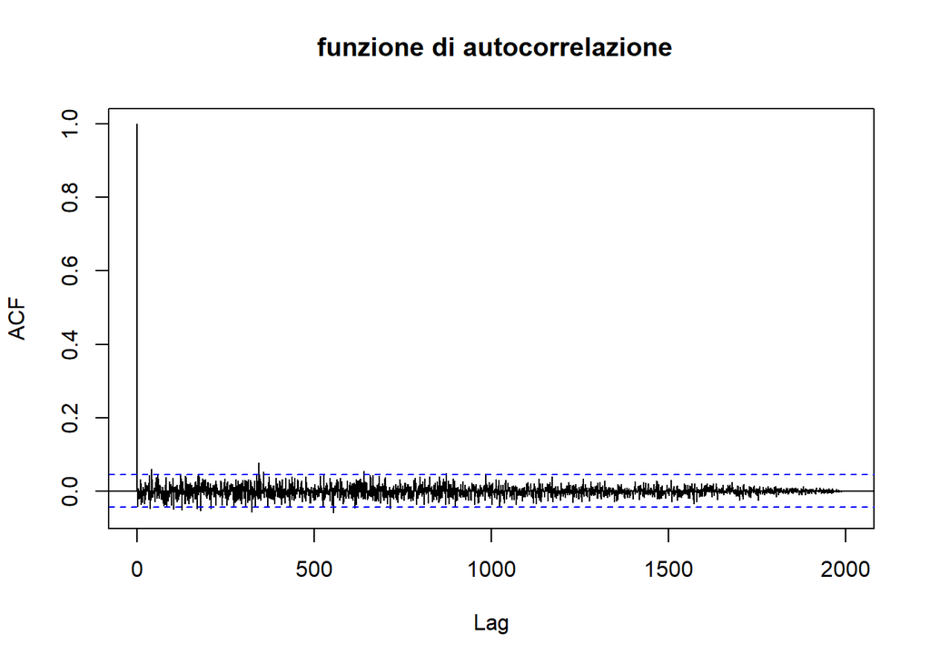

```r
acf(rand, lag.max = n,
main = " funzione di autocorrelazione")
```